# Explore Fire Samples

Michael Koontz

1/23/2018

This document represents the initial exploratory data analysis of the fire samples derived using the Earth Engine code.

```r
library(lubridate)
library(sf)
library(lme4)
library(dplyr)
library(ggplot2)
```

```r
fires <- st_read(dsn = "../data/features/fire_perim/fire_perim_sn_16_1_shp/",
                 stringsAsFactors = FALSE)
sn <- st_read("../data/features/SierraEcoregion_Jepson/SierraEcoregion_Jepson.shp") %>%
  st_transform(4326)
samps1 <- st_read("../data/fire_samples/fires-strat-samples_48-day-window_L45_none-interp.geojson")
samps2 <- st_read("../data/fire_samples/fires-strat-samples_48-day-window_L578_none-interp.geojson")
samps3 <- st_read("../data/fire_samples/fires-strat-samples_48-day-window_L78_none-interp.geojson")
samps <- rbind(samps1, samps2, samps3)
```

What fires are available for data collection in Earth Engine?

```r
glimpse(fires)
```

```
## Observations: 4,973
## Variables: 19
```

```
## $ YEAR_      <chr> "2007", "2007", "2007", "2007", "2007", "2007", "20...
## $ STATE      <chr> "CA", "CA", "CA", "CA", "CA", "CA", "CA", "CA", "CA...
## $ AGENCY     <chr> "CCO", "CCO", "CCO", "USF", "CDF", "CDF", "CDF", "C...
## $ UNIT_ID    <chr> "LAC", "KRN", "KRN", "KRN", "FKU", "MMU", "AEU", "A...
## $ FIRE_NAME  <chr> "GORMAN", "MOUNTAIN", "WHITE", "WOFFORD", "AUBERRY"...
## $ INC_NUM    <chr> "00109398", "00717959", "00018055", "00000000", "00...
## $ ALARM_DATE <date> 2007-05-19, 2007-07-19, 2007-06-24, 2007-05-09, 20...
## $ CONT_DATE  <date> 2007-05-22, 2007-07-19, 2007-06-29, 2007-05-13, 20...
## $ CAUSE      <dbl> 14, 14, 2, 9, 10, 14, 7, 14, 1, 1, 14, 7, 1, 1, 2, ...
## $ COMMENTS   <chr> NA, NA, NA, NA, NA, NA, NA, NA, "Part of the Inyo C...
## $ REPORT_AC  <dbl> NA, 840.56, 12432.15, 567.00, 150.00, NA, 126.00, 1...
## $ GIS_ACRES  <dbl> 2.373845e+03, 8.405583e+02, 1.243216e+04, 5.674566e...
## $ C_METHOD   <dbl> 8, 1, 7, 2, 2, 6, 1, 6, 2, 1, 2, 1, 6, 2, 7, 2, 6, ...
## $ OBJECTIVE  <dbl> 1, 1, 1, 1, 1, 1, 1, 1, 1, 1, 1, 1, 2, 1, 1, 1, 1, ...
## $ FIRE_NUM   <chr> "00109398", "00717959", "00718055", "0713610", "000...
## $ Shape_Leng <dbl> 19693.2088, 10229.1152, 42225.3117, 7154.9983, 3302...
## $ Shape_Area <dbl> 9.606609e+06, 3.401619e+06, 5.031117e+07, 2.296415e...
## $ FID        <dbl> 0, 0, 0, 0, 0, 0, 0, 0, 0, 0, 0, 0, 0, 0, 0, 0, 0, ...
## $ geometry   <simple_feature> MULTIPOLYGON (((109769.1290..., MULTIPOL...
```

```r
fires %>%
  filter(YEAR_ >= 1982) %>%
  group_by(YEAR_) %>%
  tally()
```

```
## Simple feature collection with 35 features and 2 fields
## geometry type:  MULTIPOLYGON
## dimension:      XY
## bbox:           xmin: -137887.3 ymin: -360668.2 xmax: 185293.1 ymax: 266928
## epsg (SRID):    NA
## proj4string:    +proj=aea +lat_1=34 +lat_2=40.5 +lat_0=0 +lon_0=-120 +x_0=0 +y_0=-4000000 +datum=NAD83 +units=m +no_defs
## # A tibble: 35 x 3
##    YEAR_     n          geometry
##    <chr> <int>  <simple_feature>
##  1  1982    25 <MULTIPOLYGON...>
##  2  1983    22 <MULTIPOLYGON...>
##  3  1984    56 <MULTIPOLYGON...>
##  4  1985    60 <MULTIPOLYGON...>
##  5  1986    46 <MULTIPOLYGON...>
##  6  1987    81 <MULTIPOLYGON...>
##  7  1988    89 <MULTIPOLYGON...>
##  8  1989    37 <MULTIPOLYGON...>
##  9  1990    60 <MULTIPOLYGON...>
## 10  1991    24 <MULTIPOLYGON...>
## # ... with 25 more rows
```

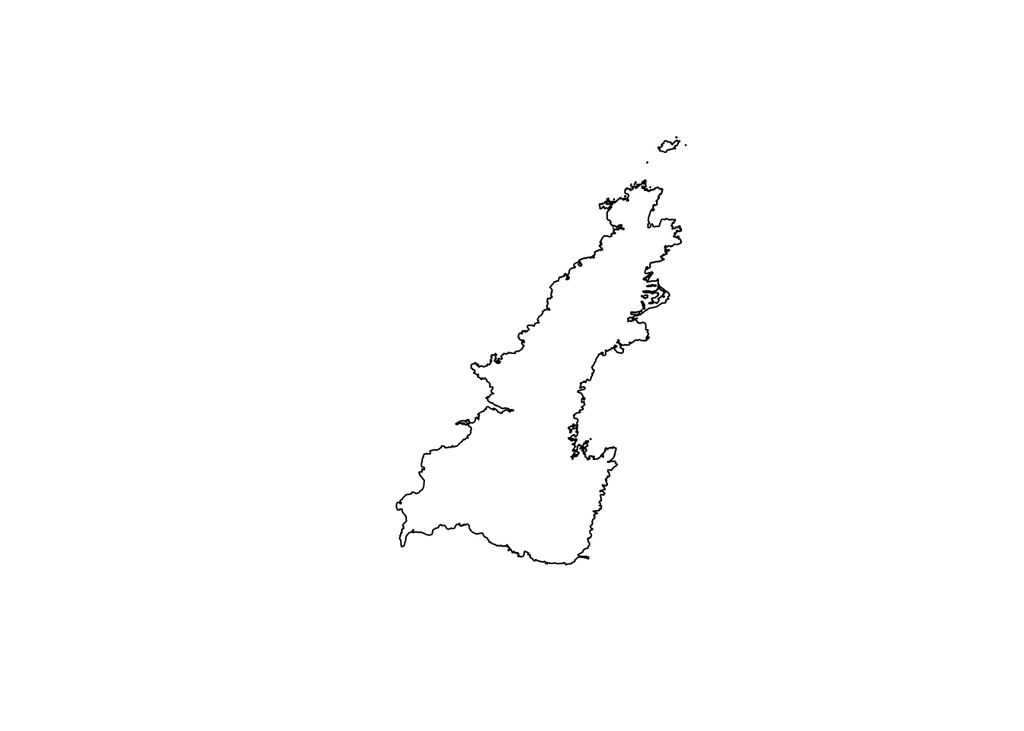

```r
fires %>%
  filter(YEAR_ == 2014) %>%
  filter(FIRE_NAME == "KING") %>%
  select(geometry) %>%
  plot()
```

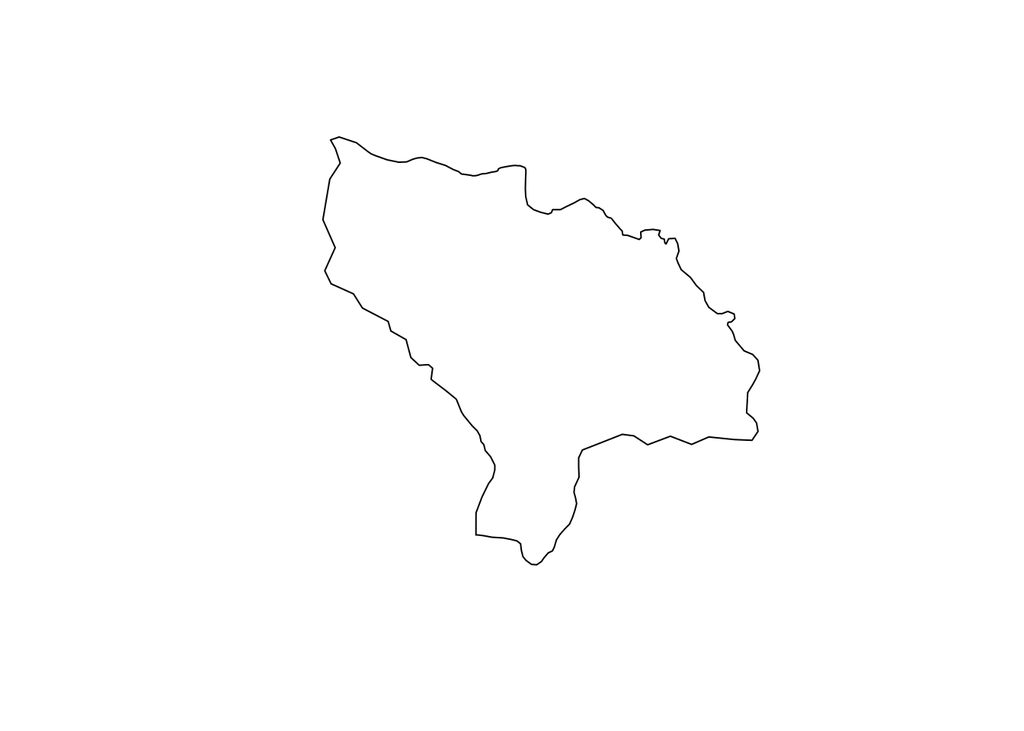

```r
fires %>%
  filter(YEAR_ == 2001) %>%
  filter(FIRE_NAME == "HIGHWAY") %>%
  filter(ALARM_DATE == "2001-07-03") %>%
  select(geometry) %>%
  plot()
```

```r
glimpse(samps)
```

```
## Observations: 62,349
## Variables: 78
## $ id                <fctr> 000079c4ef52c66a61cd_0, 000079c4ef52c66a61c...
## $ RBR               <dbl> -0.214646982, -0.169214458, -0.168366730, -0...
## $ RdEVI             <dbl> -32.9789610, -26.0048720, -27.3214767, -24.5...
## $ RdNBR             <dbl> -20.5382630, -13.3884498, -12.8841756, -10.8...
## $ RdNBR2            <dbl> -3.4288154, -1.9409796, -1.4859243, -0.56372...
## $ RdNDVI            <dbl> -16.0370597, -11.3288666, -10.8759630, -12.5...
## $ agency            <fctr> CDF, CDF, CDF, CDF, CDF, CDF, CDF, CDF, CDF...
## $ alarm_date        <dbl> 706345200000, 706345200000, 706345200000, 70...
## $ aspect            <int> 162, 200, 166, 180, 192, 212, 180, 100, 128,...
## $ cause             <int> 9, 9, 9, 9, 9, 9, 9, 9, 9, 9, 2, 2, 2, 2, 2,...
## $ comments          <fctr> , , , , , , , , , , , , , , , , , , , , , ,...
## $ conifer_forest    <int> 0, 0, 0, 0, 0, 0, 0, 0, 0, 0, 0, 0, 0, 0, 0,...
## $ dEVI              <dbl> -0.677868183, -0.649159980, -0.695373636, -0...
```

[output cut: 65 more lines]

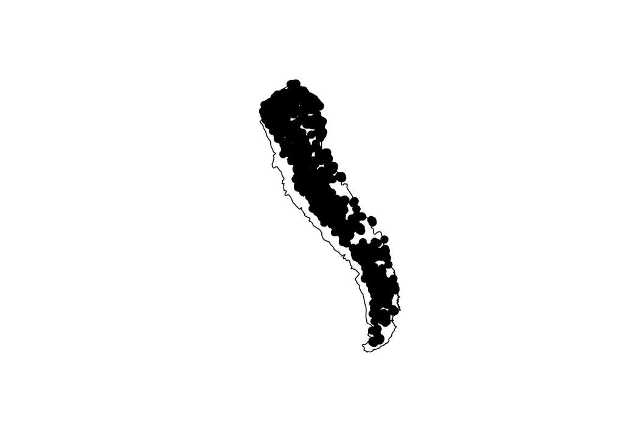

```r
# Extract unique Fire ID from the sample point IDs
samps$fire_id <- substr(as.character(samps$id), start = 1, stop = 20)

plot(samps$geometry[samps$conifer_forest == 1], pch = 19)
plot(sn$geometry, add = TRUE)
```

How many fires were processed from the FRAP database (i.e. in the Sierra Nevada and within the Landsat era)?

It looks like there are 2034 fires represented from the FRAP database with Landsat 4, 5, 7, and 8 imagery that can be processed.

# Variable adjustment

## Topography variables

Adjust aspect to reflect “heat load index” (McCune & Keon 2002) with southwest having a value of 1, and northeast having a value of -1

```r
circular_aspect <- function(aspect) {

  new_aspect <- ((-1 * (aspect)) * pi / 180) - (3/4 * pi)
  return(cos(new_aspect))

}

samps$c_aspect <- circular_aspect(samps$aspect)
```

Calculate predicted potential annual direct incident radiation (also from McCune & Keon (2002)) which combines slope, aspect, and latitude

```r
fold_aspect <- function(asp) {

  rad <- asp * pi / 180
  folded_aspect <- pi - abs(rad - pi)
  return(folded_aspect)

}

samps$folded_aspect <- fold_aspect(samps$aspect)

# G column: latitude
# H column: slope
# I column: folded aspect

# Potential
pdir <- function(lat, slope, folded_asp) {
  lat <- lat * pi / 180
  slope <- slope * pi / 180
  exp(-1.467 + 1.582 * cos(lat) * cos(slope) - 1.5 * cos(folded_asp) * sin(slope) * sin(lat) - 0.262 * sin(lat) * sin(slope) + 0.607 * sin(folded_asp) * sin(slope))
}

samps$pdir <- pdir(samps$lat, samps$slope, samps$folded_aspect)
```

Consolidate the names of the topography variables

```r
topo_vars <- c("c_aspect", "pdir", "elev", "lat", "lon", "slope", "topo_roughness_1", "topo_roughness_2", "topo_roughness_3", "topo_roughness_4")
```

## Timing variables

Adjust ordinal day to reflect “middle of summer-ness” with August 6th (the 218th day of the year) getting a 1 and February 4th (the 35th day of the year) getting a value of -1

```r
circular_doy <- function(doy) {

  new_doy <- ((doy - 218) / 365) * 2 * pi
  return(cos(new_doy))

}

samps$c_doy <- circular_doy(samps$ordinal_day)
```

Make year an integer

```r
samps$year_ <- as.numeric(as.character(samps$year_))
```

Consolidate timing variable names.

```r
timing_vars <- c("year_", "alarm_date", "cont_date", "c_doy")
```

## Vegetation variables

Consolidate vegetation variable names.

```r
veg_vars <- c("focal_mean_evi_1", "focal_mean_evi_2", "focal_mean_evi_3", "focal_mean_evi_4",
              "focal_mean_ndvi_1", "focal_mean_ndvi_2", "focal_mean_ndvi_3", "focal_mean_ndvi_4",
              "focal_mean_ndwi_1", "focal_mean_ndwi_2", "focal_mean_ndwi_3", "focal_mean_ndwi_4",
              "het_evi_1", "het_evi_2", "het_evi_3", "het_evi_4",
              "het_ndvi_1", "het_ndvi_2", "het_ndvi_3", "het_ndvi_4",
              "het_ndwi_1", "het_ndwi_2", "het_ndwi_3", "het_ndwi_4",
              "preFire_evi",
              "preFire_ndvi",
              "preFire_ndwi")
```

## Fire weather variables

Consolidate fire weather variable names.

```r
fireWeather_vars <- c("erc", "fm100", "tmmx")
```

# Scale all predictor variables

First consolidate all variable names.

```r
all_vars <- c(topo_vars, timing_vars, veg_vars, fireWeather_vars)
```

Just focus on the points from the mixed conifer/yellow pine forest

```r
mixed_con <-
  samps %>%
  filter(conifer_forest == 1)
```

How many fires have samples from mixed conifer regions in the Sierra Nevada? Our dataset contains 44216 points from 992 fires.

Scale the predictors (ss = scaled samples)

```r
ss <-
  mixed_con %>%
  mutate_at(.vars = all_vars, .funs = funs(s = as.numeric(scale(.))))

glimpse(ss)
```

```
## Observations: 44,216
## Variables: 127
## $ id                  <fctr> 00003f335ad8739e31a2_10, 00003f335ad8739e...
## $ RBR                 <dbl> 0.30710542, -0.01424231, 0.19587722, 0.252...
## $ RdEVI               <dbl> 25.263871, -5.183114, 16.317775, 18.695601...
## $ RdNBR               <dbl> 19.8872169, -0.9810927, 12.9485736, 18.082...
## $ RdNBR2              <dbl> 9.434727, 0.371924, 7.787085, 8.303005, 13...
## $ RdNDVI              <dbl> 12.334997, -1.809493, 6.431820, 9.324181, ...
## $ agency              <fctr> CDF, CDF, CDF, CDF, CDF, CDF, CDF, CDF, C...
## $ alarm_date          <dbl> 713948400000, 713948400000, 713948400000, ...
## $ aspect              <int> 296, 71, 7, 314, 342, 316, 337, 15, 0, 346...
## $ cause               <int> 10, 10, 10, 10, 10, 10, 10, 10, 10, 10, 10...
## $ comments            <fctr> 20090305, 20090305, 20090305, 20090305, 2...
## $ conifer_forest      <int> 1, 1, 1, 1, 1, 1, 1, 1, 1, 1, 1, 1, 1, 1, ...
## $ dEVI                <dbl> 1.0904414, -0.1914074, 0.6846417, 0.631221...
```

[output cut: 114 more lines]

# Build some models

We will use the Relative Burn Ratio (RBR) from (Parks *et al.* 2014) as our response variable. Look at models at different scales

```r
m1 <- lmer(RBR ~ het_ndvi_1_s * fm100_s + preFire_ndvi_s + topo_roughness_1_s + pdir_s + (1 | fire_id), data = ss)
m2 <- lmer(RBR ~ het_ndvi_2_s * fm100_s + preFire_ndvi_s + topo_roughness_2_s + pdir_s + (1 | fire_id), data = ss)
m3 <- lmer(RBR ~ het_ndvi_3_s * fm100_s + preFire_ndvi_s + topo_roughness_3_s + pdir_s + (1 | fire_id), data = ss)
m4 <- lmer(RBR ~ het_ndvi_4_s * fm100_s + preFire_ndvi_s + topo_roughness_4_s + pdir_s + (1 | fire_id), data = ss)

summary(m1)
```

```
## Linear mixed model fit by REML ['lmerMod']
## Formula:
## RBR ~ het_ndvi_1_s * fm100_s + preFire_ndvi_s + topo_roughness_1_s +
##     pdir_s + (1 | fire_id)
##    Data: ss
##
## REML criterion at convergence: -77812
##
## Scaled residuals:
##     Min      1Q  Median      3Q     Max
## -5.7658 -0.5655 -0.0718  0.4798  4.8474
##
## Random effects:
##  Groups   Name        Variance Std.Dev.
##  fire_id  (Intercept) 0.008059 0.08977
##  Residual             0.009281 0.09634
## Number of obs: 44216, groups:  fire_id, 992
##
## Fixed effects:
##                        Estimate Std. Error t value
## (Intercept)           0.1095493  0.0029085   37.67
## het_ndvi_1_s         -0.0024714  0.0005621   -4.40
## fm100_s              -0.0190253  0.0026482   -7.18
## preFire_ndvi_s        0.0287283  0.0007945   36.16
## topo_roughness_1_s    0.0037897  0.0006424    5.90
## pdir_s                0.0137688  0.0006573   20.95
## het_ndvi_1_s:fm100_s  0.0008335  0.0005430    1.53
##
## Correlation of Fixed Effects:
##             (Intr) ht__1_ fm100_ prFr__ tp__1_ pdir_s
## het_ndv_1_s -0.001
## fm100_s     -0.003 -0.002
## preFr_ndv_s  0.001  0.258  0.018
## tp_rghns_1_ -0.002  0.036  0.016 -0.003
## pdir_s      -0.001  0.019 -0.019  0.099  0.129
## ht__1_:100_ -0.010 -0.071 -0.004 -0.011 -0.009  0.029
```

```r
summary(m2)
```

```
## Linear mixed model fit by REML ['lmerMod']
## Formula:
## RBR ~ het_ndvi_2_s * fm100_s + preFire_ndvi_s + topo_roughness_2_s +
##     pdir_s + (1 | fire_id)
##    Data: ss
##
## REML criterion at convergence: -77816.4
##
## Scaled residuals:
##     Min      1Q  Median      3Q     Max
## -5.7336 -0.5657 -0.0715  0.4814  4.8497
##
## Random effects:
##  Groups   Name        Variance Std.Dev.
##  fire_id  (Intercept) 0.008073 0.08985
##  Residual             0.009280 0.09633
## Number of obs: 44216, groups:  fire_id, 992
##
## Fixed effects:
##                        Estimate Std. Error t value
## (Intercept)           0.1094566  0.0029111   37.60
## het_ndvi_2_s         -0.0012899  0.0006127   -2.11
## fm100_s              -0.0189189  0.0026503   -7.14
## preFire_ndvi_s        0.0291679  0.0007952   36.68
## topo_roughness_2_s    0.0047806  0.0006853    6.98
## pdir_s                0.0138837  0.0006568   21.14
## het_ndvi_2_s:fm100_s  0.0015923  0.0005805    2.74
##
## Correlation of Fixed Effects:
##             (Intr) ht__2_ fm100_ prFr__ tp__2_ pdir_s
## het_ndv_2_s -0.002
## fm100_s     -0.003 -0.007
## preFr_ndv_s  0.001  0.260  0.017
## tp_rghns_2_ -0.002  0.037  0.020 -0.010
## pdir_s      -0.001  0.021 -0.019  0.099  0.123
## ht__2_:100_ -0.014 -0.053 -0.006  0.000 -0.015  0.030
```

```r
summary(m3)
```

```
## Linear mixed model fit by REML ['lmerMod']
## Formula:
## RBR ~ het_ndvi_3_s * fm100_s + preFire_ndvi_s + topo_roughness_3_s +
##     pdir_s + (1 | fire_id)
##    Data: ss
##
## REML criterion at convergence: -77822.9
##
## Scaled residuals:
##     Min      1Q  Median      3Q     Max
## -5.7339 -0.5644 -0.0717  0.4810  4.8483
##
## Random effects:
##  Groups   Name        Variance Std.Dev.
##  fire_id  (Intercept) 0.008081 0.08990
##  Residual             0.009278 0.09632
## Number of obs: 44216, groups:  fire_id, 992
##
## Fixed effects:
##                        Estimate Std. Error t value
## (Intercept)           1.094e-01  2.913e-03   37.56
## het_ndvi_3_s         -5.461e-06  6.566e-04   -0.01
## fm100_s              -1.888e-02  2.652e-03   -7.12
## preFire_ndvi_s        2.958e-02  7.937e-04   37.27
## topo_roughness_3_s    5.399e-03  7.113e-04    7.59
## pdir_s                1.390e-02  6.558e-04   21.20
## het_ndvi_3_s:fm100_s  1.905e-03  6.170e-04    3.09
##
## Correlation of Fixed Effects:
##             (Intr) ht__3_ fm100_ prFr__ tp__3_ pdir_s
## het_ndv_3_s -0.002
## fm100_s     -0.003 -0.011
## preFr_ndv_s  0.000  0.253  0.015
## tp_rghns_3_ -0.003  0.028  0.023 -0.018
## pdir_s      -0.001  0.019 -0.019  0.099  0.111
## ht__3_:100_ -0.017 -0.032 -0.007  0.014 -0.014  0.028
```

```r
summary(m4)
```

```
## Linear mixed model fit by REML ['lmerMod']
## Formula:
## RBR ~ het_ndvi_4_s * fm100_s + preFire_ndvi_s + topo_roughness_4_s +
##     pdir_s + (1 | fire_id)
##    Data: ss
##
## REML criterion at convergence: -77827.4
##
## Scaled residuals:
##     Min      1Q  Median      3Q     Max
## -5.7493 -0.5641 -0.0717  0.4816  4.8505
##
## Random effects:
##  Groups   Name        Variance Std.Dev.
##  fire_id  (Intercept) 0.008084 0.08991
##  Residual             0.009277 0.09632
## Number of obs: 44216, groups:  fire_id, 992
##
## Fixed effects:
##                        Estimate Std. Error t value
## (Intercept)           0.1093398  0.0029132   37.53
## het_ndvi_4_s          0.0011145  0.0006911    1.61
## fm100_s              -0.0189095  0.0026522   -7.13
## preFire_ndvi_s        0.0298694  0.0007913   37.75
## topo_roughness_4_s    0.0056236  0.0007312    7.69
## pdir_s                0.0138595  0.0006549   21.16
## het_ndvi_4_s:fm100_s  0.0020419  0.0006474    3.15
##
## Correlation of Fixed Effects:
##             (Intr) ht__4_ fm100_ prFr__ tp__4_ pdir_s
## het_ndv_4_s -0.003
## fm100_s     -0.003 -0.013
## preFr_ndv_s  0.000  0.241  0.015
## tp_rghns_4_ -0.003  0.019  0.025 -0.025
## pdir_s      -0.001  0.017 -0.019  0.098  0.100
## ht__4_:100_ -0.020 -0.019 -0.008  0.019 -0.013  0.025
```

```r
AIC(m1, m2, m3, m4)
```

```
##    df       AIC
## m1  9 -77794.02
## m2  9 -77798.43
## m3  9 -77804.91
## m4  9 -77809.38
```

Correlations amongst response variables?

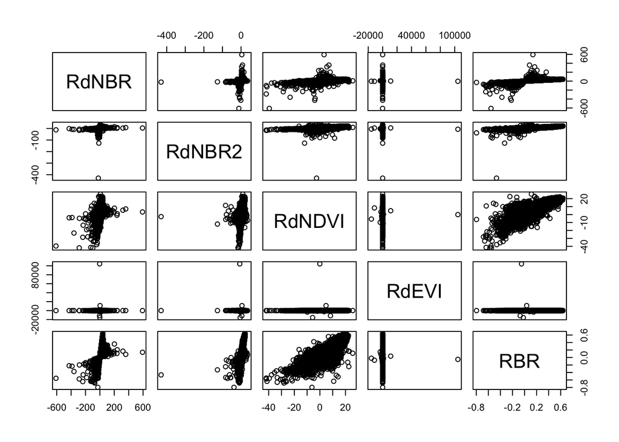

```r
pairs(samps[, c("RdNBR", "RdNBR2", "RdNDVI", "RdEVI", "RBR"), drop = TRUE])
```

Consider switching to a “high severity” / “not high severity” boolean response.

Many (all?) researchers use the categorical response because remotely-sensed severity metrics tend to have a non-linear relationship with on-the-ground severity

```r
model_summary <- read.csv("../data/cbi_calibration_model_comparison.csv", stringsAsFactors = FALSE)
target_model <- model_summary[model_summary$response == "RBR" &
                                model_summary$time_window == 48 &
                                model_summary$interpolation == "bicubic", ]
```

- 0.0421237 equates to a CBI of 0
- 0.0450966 equates to a CBI of 0.1 – threshold between “unchanged” and “low”
- 0.1125589 equates to a CBI of 1.25 – threshold between “low” and “medium”
- 0.2823349 equates to a CBI of 2.25 – threshold between “medium” and “high”

```r
ss$stand_replacing <- ifelse(ss$RBR > target_model$hi_sev, yes = 1, no = 0)
```

Our modeling effort then becomes a generalized linear model with a logit link, estimating how different covariate affect the *probability* of a high severity fire

```r
glm1 <- glmer(stand_replacing ~ het_ndvi_1_s * fm100_s +
                preFire_ndvi_s +
                topo_roughness_1_s +
                pdir_s +
                (1 | fire_id),
              data = ss,
              family = "binomial",
              control = glmerControl(optimizer = "bobyqa"))

summary(glm1)
```

```
## Generalized linear mixed model fit by maximum likelihood (Laplace
##   Approximation) [glmerMod]
##  Family: binomial  ( logit )
## Formula:
## stand_replacing ~ het_ndvi_1_s * fm100_s + preFire_ndvi_s + topo_roughness_1_s +
##     pdir_s + (1 | fire_id)
##    Data: ss
## Control: glmerControl(optimizer = "bobyqa")
##
##      AIC      BIC   logLik deviance df.resid
##  24320.3  24389.8 -12152.1  24304.3    44208
##
## Scaled residuals:
##     Min      1Q  Median      3Q     Max
## -4.1341 -0.3129 -0.0928 -0.0511 13.6298
##
## Random effects:
##  Groups  Name        Variance Std.Dev.
##  fire_id (Intercept) 6.179    2.486
## Number of obs: 44216, groups:  fire_id, 992
##
## Fixed effects:
##                      Estimate Std. Error z value Pr(>|z|)
## (Intercept)          -3.82724    0.10938  -34.99  < 2e-16 ***
## het_ndvi_1_s         -0.06009    0.02352   -2.56   0.0106 *
## fm100_s              -0.72783    0.09079   -8.02 1.09e-15 ***
## preFire_ndvi_s        0.92572    0.03377   27.41  < 2e-16 ***
## topo_roughness_1_s    0.01722    0.02215    0.78   0.4369
## pdir_s                0.29100    0.02211   13.16  < 2e-16 ***
## het_ndvi_1_s:fm100_s -0.03854    0.02996   -1.29   0.1983
## ---
## Signif. codes:  0 '***' 0.001 '**' 0.01 '*' 0.05 '.' 0.1 ' ' 1
##
## Correlation of Fixed Effects:
##             (Intr) ht__1_ fm100_ prFr__ tp__1_ pdir_s
## het_ndv_1_s -0.006
## fm100_s      0.139  0.020
## preFr_ndv_s -0.119  0.275 -0.010
## tp_rghns_1_ -0.011  0.038  0.007 -0.019
## pdir_s      -0.059  0.011 -0.034  0.172  0.139
## ht__1_:100_  0.001  0.338  0.049 -0.005  0.002  0.018
```

The theory that we’d **really** like to test is that heterogeneity matters under some fuel/weather conditions, but is overwhelmed by extreme conditions

1. If there’s a ton of fuel (i.e., high greenness), how does that affect heterogeneity? Here are some important interacters with heterogeneity. Just a check here: neighborhood windows with very low and very high mean values of greenness should have low heterogeneity. Heterogeneity requires variation, and there can’t be variation at the extreme values of mean neighborhood greeness.

This plot is beautifully concave down:

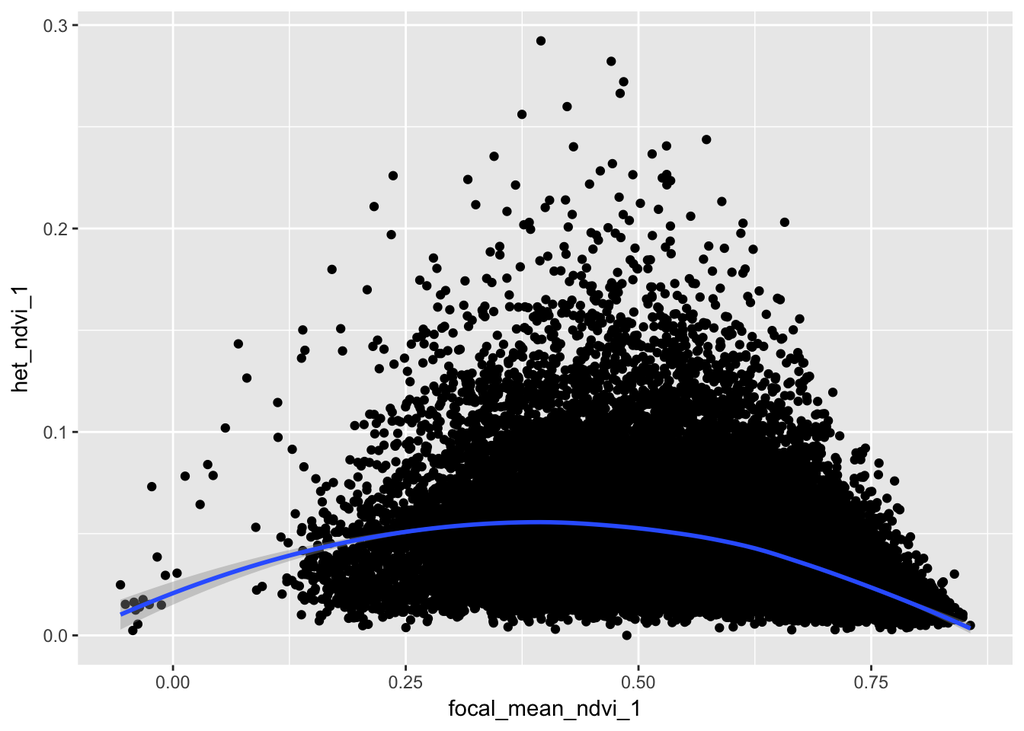

```r
ggplot(ss, aes(x = focal_mean_ndvi_1, y = het_ndvi_1)) +
  geom_point() +
  geom_smooth(method = "loess")
```

We expect that low and high mean neighborhood values of greeness (e.g., NDVI) should result in low heterogeneity. Heterogeneity requires variation, so if all nearby pixels are low or high in NDVI, then no variation is possible.

**But**, we also find that high greeness pixels tend to be around more high greenness pixels. So we just don’t get heterogeneity in places where the focal pixel is very green. You don’t get a scenario where there is a dense patch of trees, and heterogeneous forest nearby.

This plot is fairly flat until a point, then it declines quickly.

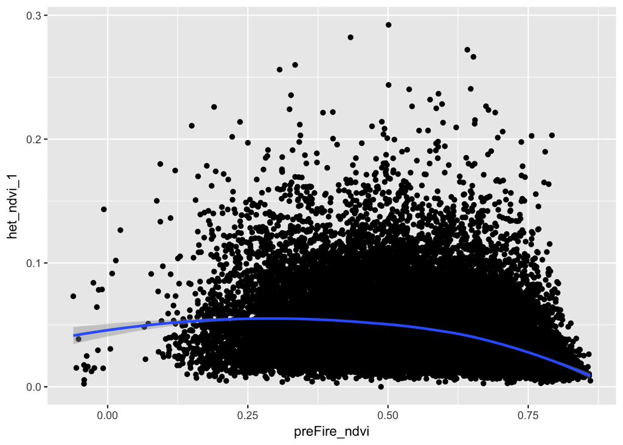

```r
ggplot(ss, aes(x = preFire_ndvi, y = het_ndvi_1)) +
  geom_point() +
  geom_smooth(method = "loess")
```

So that non-linearity poses a problem for answering the question that we really want to ask Any signal of heterogeneity is lost at high levels of greenness As an example, subset the data to only include preFire_ndvi values where heterogeneity is even (i.e., prior to the declining relationship between focal pixel greenness and heterogeneity)

```r
glm2 <- glmer(stand_replacing ~  het_ndvi_1_s * fm100_s +
                preFire_ndvi_s +
                topo_roughness_1_s +
                pdir_s +
                (1 | fire_id),
              data = ss[ss$preFire_ndvi < 0.5, ],
              family = "binomial",
              control = glmerControl(optimizer = "bobyqa"))

summary(glm2)
```

```
## Generalized linear mixed model fit by maximum likelihood (Laplace
##   Approximation) [glmerMod]
##  Family: binomial  ( logit )
## Formula:
## stand_replacing ~ het_ndvi_1_s * fm100_s + preFire_ndvi_s + topo_roughness_1_s +
##     pdir_s + (1 | fire_id)
##    Data: ss[ss$preFire_ndvi < 0.5, ]
## Control: glmerControl(optimizer = "bobyqa")
##
##      AIC      BIC   logLik deviance df.resid
##   3952.2   4012.2  -1968.1   3936.2    13390
##
## Scaled residuals:
##     Min      1Q  Median      3Q     Max
## -1.7554 -0.1327 -0.0631 -0.0305 20.5888
##
## Random effects:
##  Groups  Name        Variance Std.Dev.
##  fire_id (Intercept) 6.548    2.559
## Number of obs: 13398, groups:  fire_id, 768
##
## Fixed effects:
##                       Estimate Std. Error z value Pr(>|z|)
## (Intercept)          -2.743593   0.265788 -10.322  < 2e-16 ***
## het_ndvi_1_s         -0.164566   0.060633  -2.714  0.00665 **
## fm100_s              -0.537412   0.137845  -3.899 9.67e-05 ***
## preFire_ndvi_s        2.330039   0.150201  15.513  < 2e-16 ***
## topo_roughness_1_s    0.168497   0.062258   2.706  0.00680 **
## pdir_s                0.345380   0.067832   5.092 3.55e-07 ***
## het_ndvi_1_s:fm100_s -0.002879   0.067381  -0.043  0.96592
## ---
## Signif. codes:  0 '***' 0.001 '**' 0.01 '*' 0.05 '.' 0.1 ' ' 1
##
## Correlation of Fixed Effects:
##             (Intr) ht__1_ fm100_ prFr__ tp__1_ pdir_s
## het_ndv_1_s -0.130
## fm100_s      0.135 -0.028
## preFr_ndv_s  0.354  0.003 -0.031
## tp_rghns_1_ -0.029 -0.002 -0.012  0.061
## pdir_s      -0.061  0.004 -0.078  0.117  0.079
## ht__1_:100_ -0.050  0.195 -0.095 -0.035  0.019  0.049
```

All of a sudden, a huge impact of heterogeneity, as we expected. How best to account for this?

2. What is the relationship between different scales of heterogeneity?

Pretty highly correlated, and declining as scales diverge:

```r
cor(ss[, c("het_ndvi_1", "het_ndvi_2", "het_ndvi_3", "het_ndvi_4"), drop = TRUE])
```

```
##            het_ndvi_1 het_ndvi_2 het_ndvi_3 het_ndvi_4
## het_ndvi_1  1.0000000  0.8716866  0.7534609  0.6722532
## het_ndvi_2  0.8716866  1.0000000  0.9403858  0.8625552
## het_ndvi_3  0.7534609  0.9403858  1.0000000  0.9662741
## het_ndvi_4  0.6722532  0.8625552  0.9662741  1.0000000
```

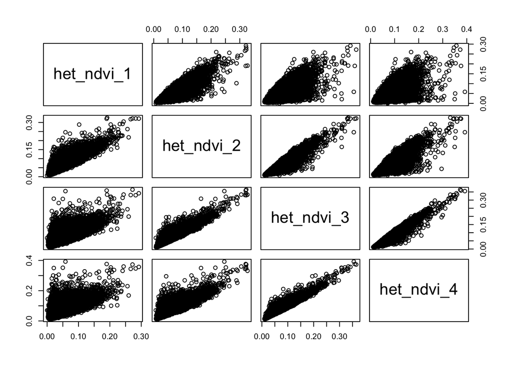

```r
pairs(ss[, c("het_ndvi_1", "het_ndvi_2", "het_ndvi_3", "het_ndvi_4"), drop = TRUE])
```

3. What is the relationship between roughness and heterogeneity?

A negative correlation:

```r
cor(ss$topo_roughness_1, ss$het_ndvi_1)
```

```
## [1] -0.07425909
```

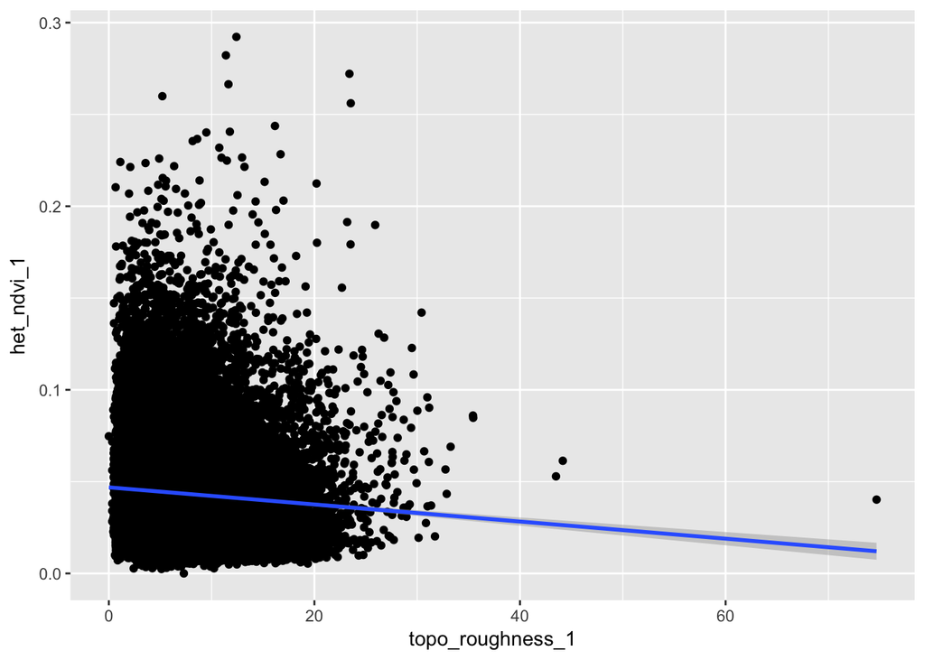

```r
ggplot(ss, aes(x = topo_roughness_1, y = het_ndvi_1)) +
  geom_point() +
  geom_smooth(method = "lm")
```

The linear regressions get the marginal effect of each variable at the *mean* of other variables:

```r
ss %>%
  summarize_at(vars(het_ndvi_1, fm100, preFire_ndvi, topo_roughness_1, pdir), mean)
```

```
## Simple feature collection with 1 feature and 5 fields
## geometry type:  MULTIPOINT
## dimension:      XY
## bbox:           xmin: -121.5576 ymin: 34.95466 xmax: -118.042 ymax: 40.41462
## epsg (SRID):    4326
## proj4string:    +proj=longlat +datum=WGS84 +no_defs
##   het_ndvi_1    fm100 preFire_ndvi topo_roughness_1      pdir
## 1 0.04392432 7.744384    0.5746048         7.345467 0.8336242
##                         geometry
## 1 MULTIPOINT (-121.5575538800...
```

And the means when subset to low NDVI at focal pixel:

```r
ss %>%
  filter(preFire_ndvi < 0.5) %>%
  summarize_at(vars(het_ndvi_1, fm100, preFire_ndvi, topo_roughness_1, pdir), mean)
```

```
## Simple feature collection with 1 feature and 5 fields
## geometry type:  MULTIPOINT
## dimension:      XY
## bbox:           xmin: -121.5549 ymin: 34.95951 xmax: -118.042 ymax: 40.41408
## epsg (SRID):    4326
## proj4string:    +proj=longlat +datum=WGS84 +no_defs
##   het_ndvi_1    fm100 preFire_ndvi topo_roughness_1      pdir
## 1 0.05373071 7.892422    0.3913357          6.79051 0.8408767
##                         geometry
## 1 MULTIPOINT (-121.5548589341...
```

What is the relationship between neighborhood mean NDVI and focal pixel NDVI?

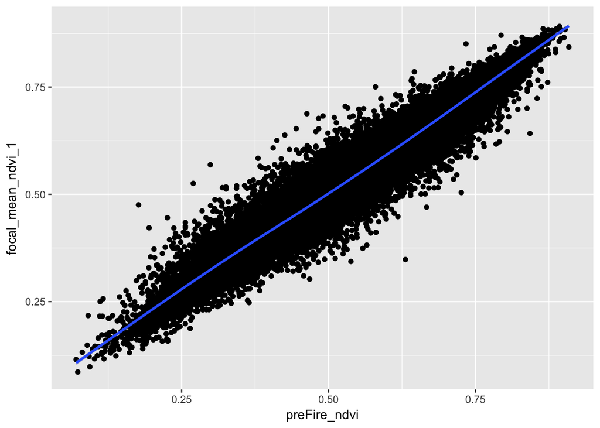

```r
ggplot(ss, aes(y = focal_mean_ndvi_1, x = preFire_ndvi)) +
  geom_point() +
  geom_smooth()
```

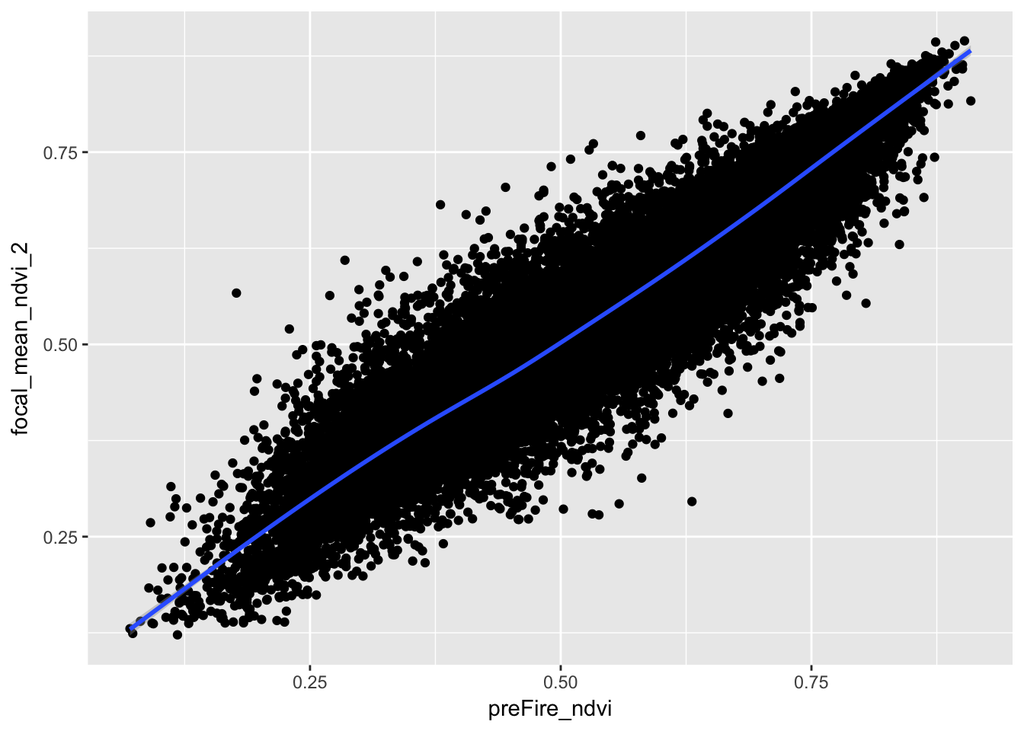

```r
ggplot(ss, aes(y = focal_mean_ndvi_2, x = preFire_ndvi)) +
  geom_point() +
  geom_smooth()
```

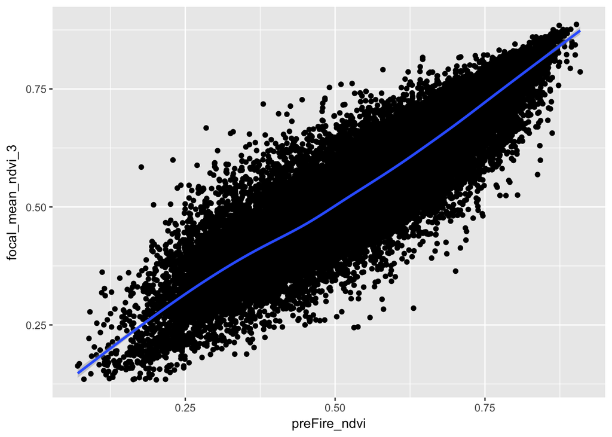

```r
ggplot(ss, aes(y = focal_mean_ndvi_3, x = preFire_ndvi)) +
  geom_point() +
  geom_smooth()
```

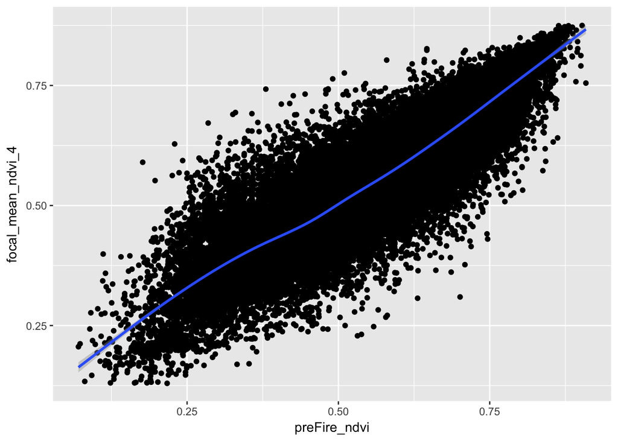

```r
ggplot(ss, aes(y = focal_mean_ndvi_4, x = preFire_ndvi)) +
  geom_point() +
  geom_smooth()
```

4. If there is high ERC or low fm100, how does that affect the impact of heterogeneity?

For 100-hour fuel moisture, we refer to Stephens *et al.* (2012) who find 7.7% to be the 80th percentile condition, 6.6% to be the 90th percentile condition, and 4.2% to be the 97.5th percentile condition. See also the note in Stephens *et al.* (2013) about the significance of 80th percentile conditions.

Create a variable for “extreme conditions” versus “non-extreme” conditions (with respect to fuel moisture) and interact it with the heterogeneity variable.

```r
# Extreme percentiles correspeond to 80th, 90th, and 97.5th percentiles of 100 hour
# fuel moisture
extreme_fm100_percentiles <- c(7.7, 6.6, 4.2)
ss$extreme80_fm100 <- ifelse(ss$fm100 < 7.7, yes = 1, no = 0)
ss$extreme90_fm100 <- ifelse(ss$fm100 < 6.6, yes = 1, no = 0)
ss$extreme97.5_fm100 <- ifelse(ss$fm100 < 4.2, yes = 1, no = 0)
```

What variables should go into this model? Additive effect of scaled pdir and scaled topographic roughness for sure, but what makes sense for the rest?

```r
extreme80_lm_1 <- lmer(RBR ~ year_ + het_ndvi_1_s +
                                 fm100_s +
                                 extreme80_fm100 +
                                 het_ndvi_1_s:extreme80_fm100 +
                                 het_ndvi_1_s:fm100_s +
                                 preFire_ndvi_s +
                                 topo_roughness_1_s +
                                 pdir_s +
                                 (1 | fire_id),
                               data = ss)
summary(extreme80_lm_1)
```

```
## Linear mixed model fit by REML ['lmerMod']
## Formula:
## RBR ~ year_ + het_ndvi_1_s + fm100_s + extreme80_fm100 + het_ndvi_1_s:extreme80_fm100 +
##     het_ndvi_1_s:fm100_s + preFire_ndvi_s + topo_roughness_1_s +
##     pdir_s + (1 | fire_id)
##    Data: ss
##
## REML criterion at convergence: -77812.3
##
## Scaled residuals:
##     Min      1Q  Median      3Q     Max
## -5.7666 -0.5652 -0.0719  0.4797  4.8482
##
## Random effects:
##  Groups   Name        Variance Std.Dev.
##  fire_id  (Intercept) 0.007786 0.08824
##  Residual             0.009281 0.09634
## Number of obs: 44216, groups:  fire_id, 992
##
## Fixed effects:
##                                Estimate Std. Error t value
## (Intercept)                  -2.8139799  0.6024337   -4.67
## year_                         0.0014564  0.0003011    4.84
## het_ndvi_1_s                 -0.0025674  0.0011025   -2.33
## fm100_s                      -0.0122481  0.0030980   -3.95
## extreme80_fm100               0.0150956  0.0045296    3.33
## preFire_ndvi_s                0.0285962  0.0007946   35.99
## topo_roughness_1_s            0.0038019  0.0006422    5.92
## pdir_s                        0.0137380  0.0006570   20.91
## het_ndvi_1_s:extreme80_fm100  0.0001164  0.0016149    0.07
## het_ndvi_1_s:fm100_s          0.0008557  0.0008041    1.06
##
## Correlation of Fixed Effects:
##             (Intr) year_  ht__1_ fm100_ e80_10 prFr__ tp__1_ pdir_s
## year_       -1.000
## het_ndv_1_s  0.003 -0.003
## fm100_s     -0.077  0.075 -0.011
## extrm80_100  0.017 -0.022 -0.014  0.531
## preFr_ndv_s  0.031 -0.031  0.108  0.014  0.001
## tp_rghns_1_ -0.009  0.009  0.028  0.012 -0.005 -0.003
## pdir_s      -0.001  0.001  0.011 -0.020 -0.008  0.099  0.129
## h__1_:80_10  0.001 -0.001 -0.860  0.010  0.015  0.027 -0.011 -0.001
## ht__1_:100_  0.007 -0.007 -0.659  0.006  0.014  0.013 -0.014  0.019
##             h__1_:8
## year_
## het_ndv_1_s
## fm100_s
## extrm80_100
## preFr_ndv_s
## tp_rghns_1_
## pdir_s
## h__1_:80_10
## ht__1_:100_  0.738
```

1.  
McCune, B. & Keon, D. (2002). Equations for potential annual direct incident radiation and heat load. *Journal of Vegetation Science*, 13, 603–606.

2.  
Parks, S.A., Dillon, G.K. & Miller, C. (2014). A new metric for quantifying burn severity: The relativized burn ratio. *Remote Sensing*, 6, 1827–1844.

3.  
Stephens, S.L., Collins, B.M. & Roller, G. (2012). Fuel treatment longevity in a Sierra Nevada mixed conifer forest. *Forest Ecology and Management*, 285, 204–212.

4.  
Stephens, S.L., Moghaddas, J.J., Edminster, C., Fiedler, C.E., Haase, S. & Harrington, M. *et al.* (2013). Fire Treatment Effects on Vegetation Structure , Fuels , and Potential Fire Severity in Western U . S . Forests. *Ecological Applications*, 19, 305–320.